# Lab5

Amanda Herbst

2024-05-17

### Lab 5 Assignment

#### Train Your Own Embeddings

Read in data

```r
setwd(here("data/offshore_wind_articles")) #where the .docxs live
post_files <- list.files(pattern = ".docx", path = getwd(),
                      full.names = TRUE, recursive = TRUE, ignore.case = TRUE)

# read list of file paths into an lnt object
wind_lnt <- lnt_read(post_files, remove_cover = FALSE)

# @ shows the objects in each "slot" of the S4 object
meta_df <- wind_lnt@meta
articles_df <- wind_lnt@articles
paragraphs_df <- wind_lnt@paragraphs

# create new dataframe with pieces of what we want to use from above
wind_df <- tibble(Date = meta_df$Date,
               Headline = meta_df$Headline,
               ID = articles_df$ID,
               Text = articles_df$Article)
```

1. Using the data from your Nexis Uni query from Week 2, create a set of word embeddings. To do this, you’ll essentially need to recreate the steps in today’s example down through the chunk named “pmi”.

Unigram probabilities

```r
unigram_probs <- wind_df %>%
  unnest_tokens(word, Text) %>%
  anti_join(stop_words, by = "word") %>%
  count(word, sort = TRUE) %>% # count frequency of each word that appears
  mutate(p = n/sum(n))

unigram_probs
```

```
## # A tibble: 8,065 × 3
##    word           n       p
##    <chr>      <int>   <dbl>
##  1 wind         716 0.0134
##  2 energy       678 0.0127
##  3 california   594 0.0111
##  4 offshore     453 0.00847
##  5 climate      433 0.00810
##  6 power        383 0.00716
##  7 clean        287 0.00537
##  8 projects     236 0.00441
##  9 plan         208 0.00389
## 10 carbon       178 0.00333
## # ℹ 8,055 more rows
```

Skipgrams

```r
skipgrams <- wind_df %>%
  unnest_tokens(ngram, Text, token = "ngrams", n = 5) %>%
  mutate(ngramID = row_number()) %>%
  tidyr::unite(skipgramID, ID, ngramID) %>%
  unnest_tokens(word, ngram) %>%
  anti_join(stop_words, by = "word")

skipgrams
```

```
## # A tibble: 265,654 × 4
##    Date       Headline                                          skipgramID word
##    <date>     <chr>                                             <chr>      <chr>
##  1 2021-08-17 1,400 customers in Rohnert Park still without po… 1_1        aug
##  2 2021-08-17 1,400 customers in Rohnert Park still without po… 1_1        17
##  3 2021-08-17 1,400 customers in Rohnert Park still without po… 1_1        power
##  4 2021-08-17 1,400 customers in Rohnert Park still without po… 1_2        17
##  5 2021-08-17 1,400 customers in Rohnert Park still without po… 1_2        power
##  6 2021-08-17 1,400 customers in Rohnert Park still without po… 1_2        rest…
##  7 2021-08-17 1,400 customers in Rohnert Park still without po… 1_3        power
##  8 2021-08-17 1,400 customers in Rohnert Park still without po… 1_3        rest…
##  9 2021-08-17 1,400 customers in Rohnert Park still without po… 1_4        rest…
## 10 2021-08-17 1,400 customers in Rohnert Park still without po… 1_5        rest…
## # ℹ 265,644 more rows
```

```r
skipgram_probs  <- skipgrams %>%
  # within each skipgram ID, counts up pairs of words
  pairwise_count(item = word, feature = skipgramID, upper = FALSE) %>% # reduce data with diag = F
  mutate(p = n/sum(n)) # create probabilities of a given pair

skipgram_probs
```

```
## # A tibble: 72,872 × 4
##    item1    item2        n          p
##    <chr>    <chr>    <dbl>      <dbl>
##  1 aug      17           2 0.00000738
##  2 aug      power        1 0.00000369
##  3 17       power        4 0.0000148
##  4 17       restored     1 0.00000369
##  5 power    restored     7 0.0000258
##  6 restored half         1 0.00000369
##  7 aug      pacific      1 0.00000369
##  8 17       pacific      2 0.00000738
##  9 power    pacific      6 0.0000222
## 10 half     pacific      2 0.00000738
## # ℹ 72,862 more rows
```

Normalize Probabilities

```r
normalized_probs <- skipgram_probs %>%
  rename(word1 = item1, word2 = item2) %>%
  left_join(unigram_probs %>%
              select(word1 = word, p1 = p), by = "word1") %>%
  left_join(unigram_probs %>%
              select(word2 = word, p2 = p), by = "word2") %>%
  mutate(p_together = p/p1/p2)

normalized_probs[1:10,]
```

```
## # A tibble: 10 × 7
##    word1    word2        n          p        p1        p2 p_together
##    <chr>    <chr>    <dbl>      <dbl>     <dbl>     <dbl>      <dbl>
##  1 aug      17           2 0.00000738 0.000187  0.000337      117.
##  2 aug      power        1 0.00000369 0.000187  0.00716         2.76
##  3 17       power        4 0.0000148  0.000337  0.00716         6.12
##  4 17       restored     1 0.00000369 0.000337  0.0000935     117.
##  5 power    restored     7 0.0000258  0.00716   0.0000935      38.6
##  6 restored half         1 0.00000369 0.0000935 0.000561       70.4
##  7 aug      pacific      1 0.00000369 0.000187  0.000599       33.0
##  8 17       pacific      2 0.00000738 0.000337  0.000599       36.6
##  9 power    pacific      6 0.0000222  0.00716   0.000599        5.17
## 10 half     pacific      2 0.00000738 0.000561  0.000599       22.0
```

```r
pmi_matrix <- normalized_probs %>%
  mutate(pmi = log10(p_together)) %>%
  cast_sparse(word1, word2, pmi)
```

Partial Decomposition

```r
# references all elements of our matrix, replace all NA values with 0
pmi_matrix@x[is.na(pmi_matrix@x)] <- 0

# factorize our matrix down to 100 dimensions
pmi_svd <- irlba::irlba(pmi_matrix, 100, verbose = FALSE)

word_vectors <- pmi_svd$u

rownames(word_vectors) <- rownames(pmi_matrix)
```

Function to estimate semantically similar words

```r
search_synonyms <- function(word_vectors, selected_vector, original_word) {

  dat <- word_vectors %*% selected_vector # dot product of matrix and our single vector
  similarities <- as.data.frame(dat) %>%
    tibble(token = rownames(dat), similarity = dat[,1]) %>%
    filter(token != original_word) %>%
    arrange(desc(similarity)) %>%  # which words are most similar to the provided word
    select(token, similarity)

  return(similarities)
}
```

```r
energy <- search_synonyms(word_vectors, word_vectors["energy",], "energy")

ocean <- search_synonyms(word_vectors, word_vectors["ocean",], "ocean")

renewable <- search_synonyms(word_vectors, word_vectors["renewable",], "renewable")
```

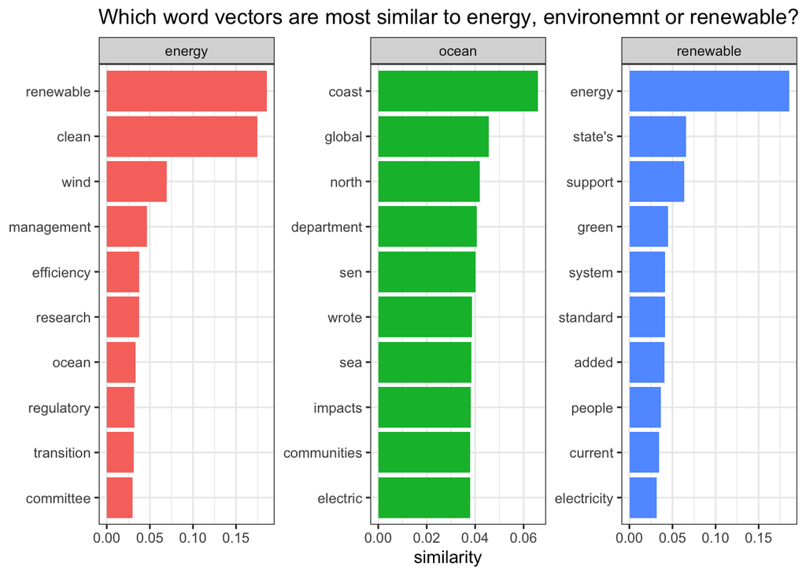

```r
energy %>%
  mutate(selected = "energy") %>%
  bind_rows(ocean %>%
              mutate(selected = "ocean")) %>%
   bind_rows(renewable %>%
              mutate(selected = "renewable")) %>%
  group_by(selected) %>%
  top_n(10, similarity) %>%
  mutate(token = reorder(token, similarity)) %>%
  ggplot(aes(token, similarity, fill = selected)) +
  geom_col(show.legend = FALSE) +
  facet_wrap(~selected, scales = "free") +
  coord_flip() +
  labs(x = NULL, title = "Which word vectors are most similar to energy, environemnt or renewable?") +
  theme_bw()
```

```r
renewable_energy <- word_vectors["renewable",] + word_vectors["energy",]
head(search_synonyms(word_vectors, selected_vector = renewable_energy, ""))
```

```
## # A tibble: 6 × 2
##   token     similarity
##   <chr>          <dbl>
## 1 energy        0.932
## 2 renewable     0.325
## 3 clean         0.166
## 4 support       0.0913
## 5 wind          0.0710
## 6 green         0.0626
```

```r
environmental_impact <- word_vectors["environmental",] + word_vectors["impacts",]
head(search_synonyms(word_vectors, environmental_impact, ""))
```

```
## # A tibble: 6 × 2
##   token         similarity
##   <chr>              <dbl>
## 1 environmental     0.861
## 2 impacts           0.443
## 3 marine            0.148
## 4 review            0.107
## 5 tribal            0.106
## 6 justice           0.0988
```

```r
MPA <- word_vectors["marine",] + word_vectors["protected",] + word_vectors["tribal",]
head(search_synonyms(word_vectors, MPA, ""))
```

```
## # A tibble: 6 × 2
##   token     similarity
##   <chr>          <dbl>
## 1 marine        0.404
## 2 impacts       0.255
## 3 life          0.113
## 4 resources     0.0898
## 5 wildlife      0.0864
## 6 fishing       0.0860
```

#### Pretrained Embeddings

4. Following the example in the SMLTR text (section 5.4), create a set of 100-dimensional GloVe word embeddings. These embeddings were trained by researchers at Stanford on 6 billion tokens from Wikipedia entries.

Note: The embeddings .zip file is very large. You may have to increase your global timeout setting to download, ex: options(timeout=100)

```r
glove6b <- embedding_glove6b(dimensions = 100)
```

Don’t have to do partial decomposition because it is already 100 dimensions!

```r
tidy_glove <- glove6b %>%
  pivot_longer(contains("d"),
               names_to = "dimension") %>%
  rename(item1 = token)

tidy_glove
```

```
## # A tibble: 40,000,000 × 3
##    item1 dimension   value
##    <chr> <chr>       <dbl>
##  1 the   d1        -0.0382
##  2 the   d2        -0.245
##  3 the   d3         0.728
##  4 the   d4        -0.400
##  5 the   d5         0.0832
##  6 the   d6         0.0440
##  7 the   d7        -0.391
##  8 the   d8         0.334
##  9 the   d9        -0.575
## 10 the   d10        0.0875
## # ℹ 39,999,990 more rows
```

5. Test them out with the canonical word math equation on the GloVe embeddings: “berlin” - “germany” + “france” = ?

Hint: you’ll need to convert the GloVe dataframe to a matrix and set the row names in order to use our synonym function.

```r
# convert to matrix and set row names as the first column
glove_matrix <- glove6b %>%
  tibble::column_to_rownames(var = "token") %>%
  as.matrix()

# test word math
word_math_test <- glove_matrix["berlin",] - glove_matrix["germany",] + glove_matrix["france",]
search_synonyms(glove_matrix, word_math_test, "")
```

```
## # A tibble: 400,000 × 2
##    token    similarity
##    <chr>         <dbl>
##  1 paris          34.4
##  2 france         31.5
##  3 french         28.0
##  4 de             28.0
##  5 le             26.6
##  6 london         25.4
##  7 la             24.3
##  8 brussels       23.3
##  9 berlin         23.3
## 10 lyon           22.2
## # ℹ 399,990 more rows
```

6. Recreate parts 2 and 3 above using the the GloVe embeddings in place of the ones you made. How do they compare? What are the implications for applications of these embeddings?

```r
energy <- search_synonyms(glove_matrix, glove_matrix["energy",], "energy")

ocean <- search_synonyms(glove_matrix, glove_matrix["ocean",], "ocean")

renewable <- search_synonyms(glove_matrix, glove_matrix["renewable",], "renewable")
```

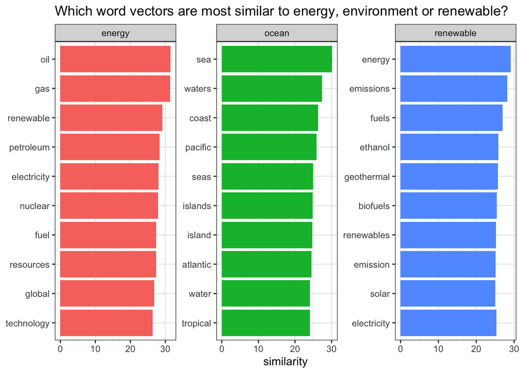

```r
energy %>%
  mutate(selected = "energy") %>%
  bind_rows(ocean %>%
              mutate(selected = "ocean")) %>%
   bind_rows(renewable %>%
              mutate(selected = "renewable")) %>%
  group_by(selected) %>%
  top_n(10, similarity) %>%
  mutate(token = reorder(token, similarity)) %>%
  ggplot(aes(token, similarity, fill = selected)) +
  geom_col(show.legend = FALSE) +
  facet_wrap(~selected, scales = "free") +
  coord_flip() +
  labs(x = NULL, title = "Which word vectors are most similar to energy, environment or renewable?") +
  theme_bw()
```

```r
renewable_energy <- glove_matrix["renewable",] + glove_matrix["energy",]
head(search_synonyms(glove_matrix, selected_vector = renewable_energy, ""))
```

```
## # A tibble: 6 × 2
##   token       similarity
##   <chr>            <dbl>
## 1 energy            70.6
## 2 renewable         69.7
## 3 gas               54.9
## 4 emissions         54.0
## 5 electricity       53.3
## 6 fuels             51.6
```

```r
environmental_impact <- glove_matrix["environmental",] + glove_matrix["impacts",]
head(search_synonyms(glove_matrix, environmental_impact, ""))
```

```
## # A tibble: 6 × 2
##   token         similarity
##   <chr>              <dbl>
## 1 environmental       54.5
## 2 impacts             48.2
## 3 climate             47.4
## 4 pollution           46.0
## 5 economic            44.2
## 6 ecological          44.2
```

```r
MPA <- glove_matrix["marine",] + glove_matrix["protected",] + glove_matrix["tribal",]
head(search_synonyms(glove_matrix, MPA, ""))
```

```
## # A tibble: 6 × 2
##   token     similarity
##   <chr>          <dbl>
## 1 marine          62.6
## 2 tribal          56.9
## 3 protected       54.1
## 4 areas           52.8
## 5 military        52.2
## 6 wildlife        51.5
```